# A3: SPL Library Checkouts

### Introduction

Using the Seattle Public Library data, I chose to analyze written works by John Green that were checked out in Seattle. I chose this author because he was very popular when I was younger, and I wanted to understand how popular his books have been recently. I was also curious about whether certain factors related to the level of popularity of his books. This leads me to my main research question:

- *How popular has works written by John Green been from 2005 to 2023?*

In order to do so, I will focus on the **Checkouts**, **Title**, **CheckoutYear**, **CheckoutMonth**, and **MaterialType** when calculating summary statistics and creating data visualizations. I will not use the “Subjects” column because many of John Green’s books fall under the same genres, and any unique genres tend to fall only under one story title. I will not be using the “PublicationYear” column due to the large variation in format. I will also only be analyzing the English versions of John Green’s works in order to exclude language as a variable (that can impact popularity) from the other variables I would like to analyze. Using my selected variables, I will analyze the following trends:

- *How have the most checked out stories written by John Green changed overtime?*
- *How have the materials of the most checked out items written by John Green’s changed overtime?*
- *How has the checkouts of John Green’s most popular story and material changed over time?*

### Summary Information

In order to assess John Green’s popularity throughout the years and factors that may be associated with his popularity, I calculated summary statistics that use the values specified in the introduction. First, I wanted to know which piece of work written by John Green was the most popular, which I found by pulling the title of the item with the most amount of checkouts. I found that the item in the Seattle Public Library written by John Green with the most number of checkouts was “The Fault In Our Stars”. For this statistic, I purposefully did not combine items with a similar book title because these differences in title formats are due to differences in the item’s material type which can potentially impact how often an item is checked out. (For instance, John Green’s book called “An Abundance of Katherines” can also be found in the dataframe under the title “An Abundance of Katherines (Unabridged)” because the two are different types of mediums.)

As for type of material, John Green’s book checkouts were most checked out as a book. I used this statistic to determine if the material type changed the popularity of a story. I filtered the data to only view checkouts whose material is a *book*, and the story with the amount of checkouts was still “The Fault In Our Stars”. This tells me that the material did not impact the most popular story. When calculating this last statistic, I did change the format of the entries in the “Title” column to match those which are the same story. (For instance, the story “Looking for Alaska” was entered as “Looking for Alaska / John Green.” and “Looking for Alaska / a novel by John Green.”. Because both entries are books, I combined theme under the same title “Looking for Alaska”. These entries also have different publishers, but because publishers don’t change the content of a story, I did not think the difference was relevant and grouped these titles under the same title.)

### The Dataset

> Who collected/published the data?
- Before 2017, George Legrady collected the checkout data since 2005 to use for his piece of artwork called “Making the Invisible Visible”. The Seattle Public Library then began data collection in 2017 and combined their data with Legrady’s data in order to publish everything to the Seattle Open Data program.
- My custom dataframe uses this data, but it is filtered to only include English checkout items written by the American author John Green.

> What are the parameters of the data (dates, number of checkouts, kinds of books, etc.)?
- In my custom dataset, there are 3216 observations/rows.
- The features/columns of the data are listed below, and there are a total of 12:
  - UsageClass (whether the check out was digital or physical)
  - CheckoutType (the vendor tool used for the check out)
  - MaterialType (the medium of the check out)
  - CheckoutYear
  - CheckoutMonth
  - Checkouts (number of check outs of the item)
  - Title (of the item checked out)
  - ISBN
  - Creator
  - Subjects (a list of genres of the item)
  - Publisher
  - PublicationYear

> How was the data collected or generated?
- The digital checkout data was collected through the Seattle Public Library’s vendors (who are Overdrive, hoopla, Freegal, and RBDigital). Data on physical checkouts was collected from the Legrady artwork data archives from 2005 to 2016 and from the Horizon ILS since 2016.

> Why was the data collected?
- According to Seattle’s Open Data website, data is published by the city’s departments and put into their Open Data program. This Open Data program was created so that the data collected by Seattle was easily accessible to the public. They wanted the availability of the data to increase Seattle’s quality of life and promote a supportive and beneficial community to its residents. The program wanted the data to be used towards its goal of constant self-improvement.
- Before this, George Legrady collected the checkout data to create his artwork that displays summarized and recent data of the library’s checkouts.

> What, if any, ethical questions do you need to consider when working with this data?
- One ethical question to consider is how the Seattle Public Library alerted its users that their data was being collected. The [article](https://shelftalkblog.wordpress.com/2022/12/06/how-a-digital-artwork-helped-the-seattle-public-library-lead-in-book-data/) that explains how the SPL checkout data came to be claims that Legrady’s data did not collect any information on its users but does not further specify how. Although the data remains anonymous, users of the library may not be comfortable with any of their check out information being collected as the items’ subjects can read into the users’ personal interests or political beliefs. Considering how many websites force a user to accept their terms and conditions in order to use the website, the library may follow a similar policy for users to check out items. This means that for users who require the use of the library’s items, they would be forced to share their data in order to access the library’s resources.

> What are possible limitations or problems with this data?
- One limitation of the data is that it does not record renewal check outs and only records the initial check out. This means that the data is likely to have underestimated the number of total check outs per month as it is common for users to extend their time limit.
- Another problem of the data is that it is very messy due to its variation in sources. The various sources used to collect the data means that different methods were used to collect different types of information. For example, the source for the physical checkouts changed during 2016, so some entries have blank fields meaning the data is inconsistent depending on what time frame is being viewed. Furthermore, the original dataset is messy as some of the entries use unreadable characters and the format of data entries differs. This can be seen when looking at the “PublicationYear” column which can make filtering for a certain data value difficult. This also includes book titles that are written in English or Spanish or written with different capitalized letters (such as “unabridged” versus “Unabridged”).
- A third problem relates to the Subjects column. The subject of each entry is a string of subjects. This means that each subject entry does not pertain to one unique subject. For example, when looking at the subjects for the book titled “An Abundance of Katherines” and comparing it to “Paper Towns”, the entire subject entry itself is different. However, after taking a closer look at each subject in the list, we are able to find that both books share Young Adult Fiction as a subject.
- Lastly, in my filtered dataset, the creator is filtered to “John Green”, but this doesn’t mean that all creators are the same person. This means that creators who share the same name are included in this dataset, so I need to further clean the data to only include items created by the American author John Green.
- In order to limit these issues in my custom dataframe, I applied multiple filters to the “Creator” column in order to obtain as many rows as possible that include the name “John Green”. Then, I went through the “Title” column in alphabetical order to check if each item was written by the American author John Green or written in a different language. I omitted any data entries that were not written in English or written by a different author. As explained in the summary information section, I did not combine the same works together (such as combining all works of “The Fault in Our Stars” because the difference in title entries were due to a difference in material type. Lastly, I did not use the ISBN column when using my custom dataset because it contained a significantly large amount of “NA” values. In the “MaterialType” column, there is an entry labeled “REGPRINT”, which I cannot find the meaning of in the Seattle Open Data Program website. To not make assumptions, I will not use “REGPRINT” when filtering the “MaterialType” column.

### First Trends Over Time Chart

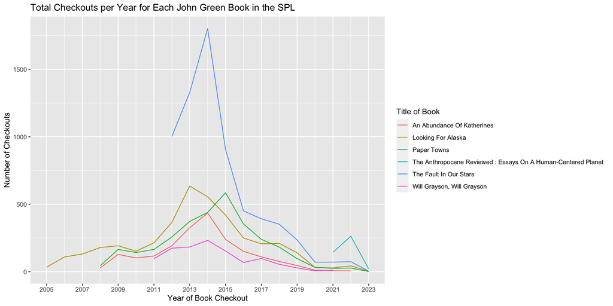

### Second Trends Over Time Chart

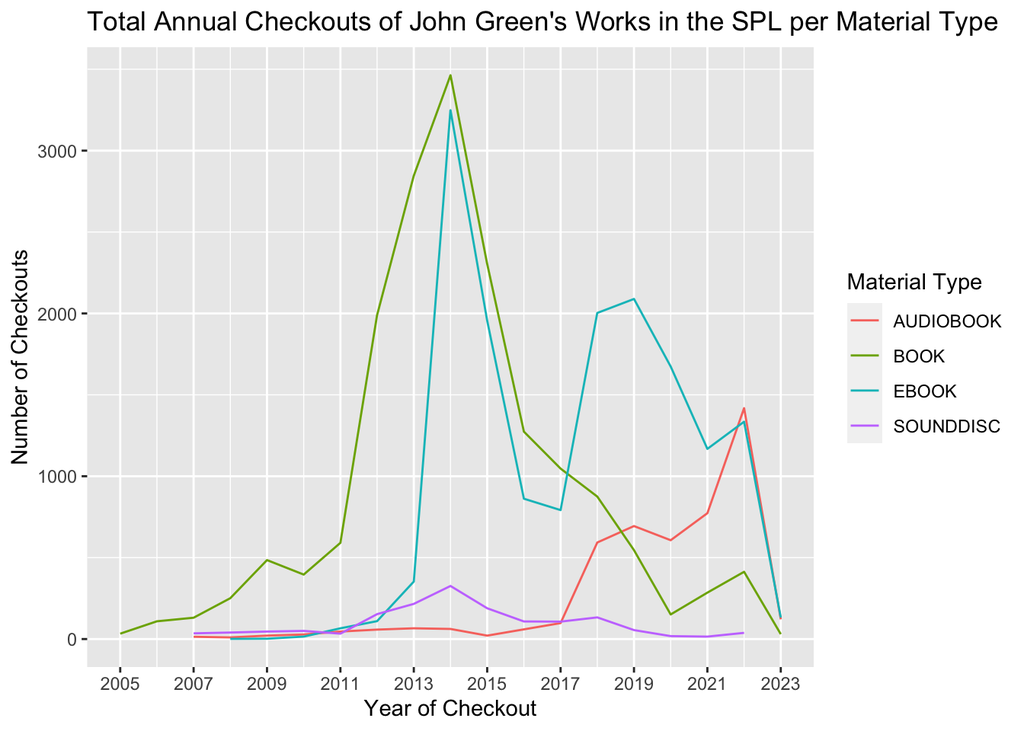

### Stacked Bar Plot

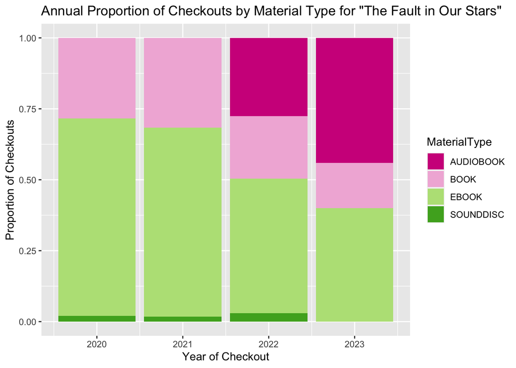

This stacked bar plot shows a proportion of annual checkout totals for “The Fault in Our Stars” from 2020 to 2023. The proportion is the annual checkout total for each material type divided by the total checkouts that year.

From Chart 1, “The Fault in Our Stars” appeared to be when John Green’s popularity dramatically peaked, so I wanted to further analyze the checkout trends of this story in recent years. More specifically, I wanted to see how the proportion of certain materials checked out changed over time, so I created stacked bars based on material type. It’s also important to note that the audiobook for “The Fault in Our Stars” in this dataset was published after the other materials which explains why there are no audiobook checkouts from January 2020 to March 2022.

The stacked bar plot reveals that specifically for “The Fault in Our Stars”, the audiobooks increased in popularity since they were released in 2022. However, more data would be required after 2023 ends to fully asses this comparison as the 2023 bar is only for January 2023’s checkouts. On average, the checkouts for ebooks are much greater than the checkouts for other materials. The sound discs make up a very small proportion of annual checkouts from 2020 to 2022. The proportion of book checkouts has also decreased since 2020.